# StatComp Project 2: Scottish weather

Lorenzo Stigliano (s1725018, LorenzoStigliano)

# 1 Weather data

```r
# Modify this code chunk to add extra packages etc if needed,
# and to load the weather data.

# Load function definitions
source("my_functions.R")

# Load common packages
suppressPackageStartupMessages(library(tidyverse))
suppressPackageStartupMessages(library(StatCompLab))
suppressPackageStartupMessages(library(shiny))

# load data in
data(ghcnd_stations, package = "StatCompLab")
data(ghcnd_values, package = "StatCompLab")

# Rename the stations such that they are more legible on the graphs
ghcnd_stations$Name[7] <- "ROYAL BOTANICAL GARDEN"
ghcnd_stations$Name[8] <- "BENMORE"

theme_set(theme_bw())
```

# 2 Climate trends and variability

In this section we hope to highlight the climate trends in Scotland by using the data from The Global Historical Climatology Network. We hope to show trends across different stations by using linear models for each month. Furthermore, we hope to check if there is any seasonally temperature variability.

## 2.1 Monthly trends

In this question we are asked to estimate the long-term temporal trend in TMIN for each month, for each weather station. To do this we have begin by finding the mean TMIN for each month of every year and then fit a linear model for each month and each station over all years.

Below I have illustrated an example of what we are doing for each month and for each station, so it is easier to visualize the data later on.

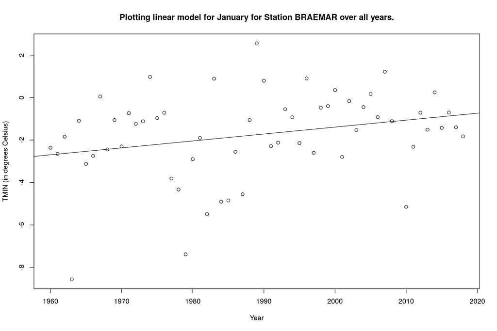

```r
# read data saved before, to find average TMIN per month
data <- readRDS(file = "data/2_1_data.rds")

# get id of the station for BRAEMAR
id <- ghcnd_stations[1, 1]

# get the month in this case January for the station of interest
month_data <- filter(data, data$Month == 1, ID == id)

# Plot the linear model and the points to show what we are doing
plot(month_data$Year, month_data$TMIN,
  main = "Plotting linear model for January for Station BRAEMAR over all years.",
  xlab = "Year", ylab = "TMIN (in degrees Celsius)"
)
abline(lm(month_data$TMIN ~ 1 + month_data$Year))
```

In this example, we can clearly see an upward trend, suggesting increasing temperatures throughout the years. But we now need to generalize this for all stations and all months. In particular we are interested in the long-term temporal trend in TMIN for each month. In order to get this information we are interested in the regression coefficients, these will give us the trend over the years. To get this information we created a function called $\textit{monthly_trends()}$ which calculates the monthly trends for each month and for each station, together with confidence intervals for the coefficient value.

In fact, the particular data structure produced by the function $\textit{monthly_trends()}$ has the of the following form:

1. Name: Name of the station
2. Id: Id of the station
3. Month: Month of interest
4. Coeff: Regression coefficient for linear model multiplied by 10, such that we can see the $\textit{change per decade}$ of the average temperature for each month.
5. Lower_Bound: Lower bound on the confidence interval for the coefficient
6. Upper_Bound: Upper bound on the confidence interval for the coefficient

Once we have the data for all months and stations we are ready to plot this. In this case what we have done is plot the regression coefficients for each month and plotted separate figures for each station, as seen below. Furthermore, when we reffer to the coefficient we will be referring to the coefficient for linear model multiplied by 10 such that it is showing use the $\textit{change per decade}$ of the average temperature for each month.

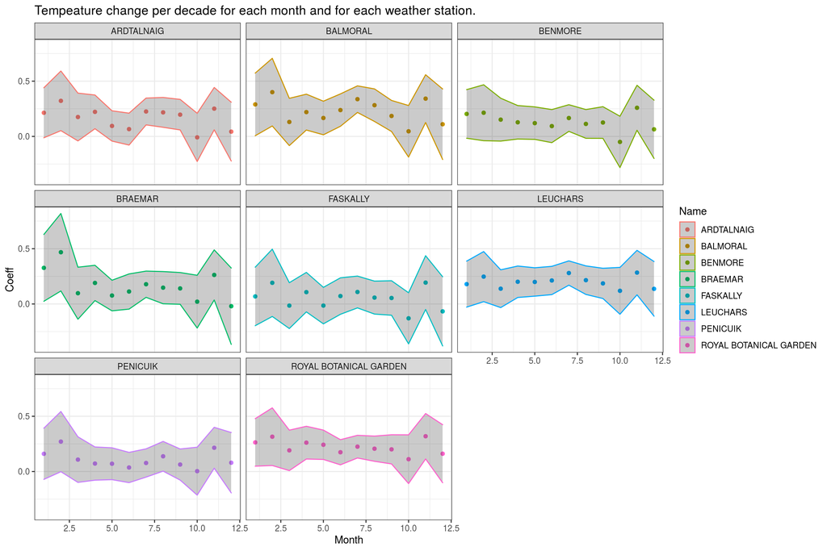

```r
# Get the coefficient data
coeff_data <- readRDS(file = "data/2_1_coeff_data.rds")
# Use the plot_coeff function to plot this data
plot_coeff(coeff_data)
```

Another question we can ask is: $\textit{Is there an average temperature change per decade?}$ We can see that most of the coefficients in all stations are between 0 and 0.5. This indicates that there has been an increase of temperature over a decade for each month. Furthermore, this patterns seems to be consistent for all stations. Therefore, there is an average temperature change per decade which is around 0.2 for all stations. This comes to no surprise, this highlights the problem of global warming which we are experiencing worldwide. In fact, our results are consistent with various reports which calculated an increase of approximately 0.2 degrees per decade (with high confidence). This article can be found at https://www.ipcc.ch/sr15/chapter/chapter-1/.

Furthermore, we can also ask ourselves: $\textit{Are there any seasonal trends?}$ When we look at the coefficients for each month, that is, the $\textit{change per decade}$ of the average TMIN temperature, we see that for all stations there does not seem to be seasonal variability. In fact, there seems to be a consistent increase in temperatures throughout all the months with no seasonal variability. Again, this makes sense since this means that the rate of increase of the temperatures are independent of the season, which suggests that an sustained increase of temperatures throughout all the months over the decades. This means that we are in fact seeing a temperature rise for all seasons, supporting the fact that global warming is in fact coming into effect. However, it is worth noting that there are small peaks in all stations, in particular in February and November. We will now explain why this is the case.

This can be explained perhaps by the seasons. We know that the seasonal changes occur on the March 1 for winter to spring and December 1 for autumn to winter. Therefore we can see that the month before these start dates in fact have a higher change per decade than other months. This suggests that the change of season is more pronounced and as a result we see higher rate of increase over these months.

Furthermore, we need to consider if these rates of change are reliable. We need to consider the time frame we are analyzing the data for. The data is collected from 1960 to 2018. Since we are only dealing with a 58 year range we can in fact use this analysis for how the climate trend varies. Suppose we where dealing with a wider range from years for example from 1960 back to the year 0. Then our linear models would in assume that our temperatures can go back to the intercept of the model, that is when the year is 0. If we look at the y-intercept for the BRAEMAR linear models for each month as seen from the table below we can see that most of them are negative with the largest value at 2.70 and the smallest at -95.15. Therefore, it would not make sense to generalize this analysis if we are dealing with larger time periods. Since it assumes that we have very extreme negative temperatures for the several months at the year 0 which we know is not the case.

```r
# Get the intercepts and the stations
intercepts <- coeff_data %>%
  filter(ID == id) %>%
  select(c(Month, Intercept))

# Show the intercepts of one month of the models created
knitr::kable(intercepts, digits = 3)
```

| Month | Intercept |
| --- | --- |
| 1 | -66.713 |
| 2 | -95.152 |
| 3 | -19.927 |
| 4 | -36.807 |
| 5 | -11.650 |
| 6 | -15.582 |
| 7 | -26.959 |
| 8 | -21.157 |
| 9 | -21.586 |
| 10 | -0.309 |
| 11 | -51.772 |
| 12 | 2.700 |

## 2.2 Seasonally varying variability

For the rest of the project we will focus on the BRAMEAR weather station.

In this question we are asked to perform a randomization test for whether the the variance of the daily TMIN residuals from the monthly averages is larger than the overall residual variance for each month. To do this we will work with the residuals, these are given by $R_t = \text{TMIN}_t - \text{TMIN}_{M(t)}$. That is from the daily $\text{TMIN}_t$ we subtract the average $\text{TMIN}$ of the month $M$ it came from $\text{TMIN}_{M(t)}$.

In our case, the hypothesis for each month that should be tested aregiven in the following form:
$$H_0 = \text{The residual variance is the same for all months of the year.}\\
H_1 = \text{The residual variance of Janurary is} \textbf{ greater } \text{ than the overall variance.}$$
Notice that we can change January for any other month. As a result our test statistic will be in the form of:
$$T = Var(\text{Residuals for January}) - Var(\text{Residuals for all months})$$
Where, again, January can be any month. Notice that we will be doing a one sided test, since we want to see of if the residual for each month is $\textbf{greater}$ than the residuals for all months. To do this we run the randomization test by using the $\textit{randomisation_test()}$ function. In particular, we are interested in the proportions of permutations that are $\textbf{greater}$ than the test statistic $T$, this will be the p-value of our test. Furthermore, the number of permutations used was 2500, such that the bound on the estimation standard deviation is $\leq 0.01.$

```r
# Load in the p-values calculated
p_values <- readRDS(file = "data/2_2_p_values.rds")
# Display the p-values for each month
knitr::kable(p_values, digits = 3)
```

| Month | Month_Residuals_Var | P_Value_One_Sided | P_Value_Two_Sided |
| --- | --- | --- | --- |
| 1 | 18.676 | 0.000 | 0.000 |
| 2 | 17.788 | 0.000 | 0.000 |
| 3 | 12.314 | 0.602 | 0.795 |
| 4 | 10.053 | 1.000 | 0.000 |
| 5 | 9.952 | 1.000 | 0.000 |
| 6 | 8.079 | 1.000 | 0.000 |
| 7 | 6.935 | 1.000 | 0.000 |
| 8 | 9.355 | 1.000 | 0.000 |
| 9 | 10.993 | 0.999 | 0.002 |
| 10 | 12.173 | 0.698 | 0.603 |
| 11 | 15.201 | 0.000 | 0.000 |
| 12 | 18.135 | 0.000 | 0.000 |

The table above shows us the p-values for all the months for the weather station BRAMEAR. We can see that the following months: January, February, November and December have p-values equal to 0. Since the p-value < 0.01, we reject $H_0$ in favor of $H_1$ for these months at the 0.01 level. The remaining months, that is, March, April, May, June, July, August, September and October, since these p-values are greater than 0.01, we do not reject $H_0$ in favor of $H_1$ at the 0.01 significance level.

But what does this mean? For the months January, February, November and December we know that the we have reject $H_0$ in favor of $H_1$, as a result, we have enough evidence to conclude that the residuals variance for these months is greater than all the residual for all months. In fact, this can be seen from the $\textbf{Month_Residuals}$ column. This suggests that the variability of temperatures for these months is much greater. That is the daily $\text{TMIN}$ fluctuate away from $\text{TMIN}_{M(t)}$. As a result, this means that the colder months, that is the winter months, have days where many days are warm and many other days are colder than the mean. Suggesting volatility in temperatures recorded. In contrast to the warmer months that have a large p-value which suggests that the residual variance is in fact small again this can be seen from the $\textbf{Month_Residuals}$ column. Perhaps, to explain why $\text{TMIN}$ temperatures vary more in winter months in contrast to the summer months could be because if we look at the rates of change temperatures for the first graph we in fact see that in particular February and November had a higher rate of change per decade than the other months as a result this could indicate more volatile $\text{TMIN}$ temperatures in these months, and as a result we see high variance of the residuals.

To conclude we need to answer the question, $\textit{Is the temperature variability the same for each month of the year?}$ As we have seen from the one sided test is that this is not the case, in fact we saw that the winter months had higher variability. Furthermore, when we carried out the two sided test we also had evidence to suggest that the summer months did not have the same variability. Furthermore, it is worth mentioning that months 3 and 10, that is March and October, did not have significant temperature variability in both the one-sided and two-sided tests since in both case the p-values where between 0.6 and 0.8.

# 3 Spatial weather prediction

We will now shift out attention to building models for weather prediction, in particular we are interested in building linear models to predict the daily $\text{TMAX}$ of a given station by using the daily $\text{TMAX}$ from other stations as the covariates. We hope to be able to good models and then asses them to see how well they are preforming. Being able to predict temperatures by using other stations is particularly important. An example of the usage of linear models, is for example, suppose if a station went down and could not produce results, then we could make a prediction of what the weather was like on a given day. Furthermore, being able to predict temperatures is an important attribute to forecast. This is because agriculture sectors, as well as many other industries, are largely dependent on the weather conditions, thus being able to produce good models is key for these sectors to operate optimally.

## 3.1 Estimation

In this part of the project we are asked to choose a weather station, and make code for estimating a linear model that uses daily $\text{TMAX}$ at the other weather stations as covariates for $\text{TMAX}$ at the chosen station.

Again, like in the previous section we will be using the BRAMEAR weather station.

To do this we have created a linear model using the daily $\text{TMAX}$ at the other stations as the covariates to predict the daily $\text{TMAX}$ at BRAMEAR which in this case is the dependent variable of the linear model.To do this we need to first augment the data such that we have columns for each of the stations with the daily $\text{TMAX}$ values as their entries. In order to be able to make this linear model. I have augmented the data in my_code.R file in the “Question 3.1 setup” section. What we have done:

1. First renamed the columns of “ROYAL BOTANICAL GARDEN” and “BENMORE” such that they are more legible when we plot them.
2. We then joined ghcnd_values and ghcnd_stations data by ID, these data sets are the ones given to us.
3. Then we pivot wider the Elements column such that we can get a column for $\text{TMAX}$
4. We then picked the columns of interest in particular: $\text{TMAX}$, Year, Month, Day and Name.
5. We pivot wider again but this case on Name such that we create columns for each of the stations which have the $\text{TMAX}$ value for the given day as their entry. This step was vital in order to be able to use the other stations as the covariates of our linear model.
6. We dropped any row with NA values.
7. Finally, we added a new column to this data frame called “Date” which allows us to plot time series data easily as we shall see later.

This data frame will be used throughout this section. For both the Estimation and the Prediction sections.

Once we have this data frame we are ready to create linear models for each month for the daily TMAX for BRAMEAR as the dependent variable and the other stations daily TMAX as covairates of the linear model. We use the function $\textit{get_model_coeff()}$ to get the coefficients for the models for each month.

It is important to understand why we are fitting a linear model for each month, why don’t we just fit one model for all the months? When fitting regression models to seasonal time series data to estimate monthly or quarterly effects, one needs to be able to take these into account differences in the seasons by using different models. This is because we know that the temperatures for the winter months are smaller than that of the summer months and as a result it is vital to be able to produce different models for each month. As a result, by incorporating our knowledge about the different temperatures for each month we can create better linear models to predict daily $\text{TMAX}$ temperatures. Furthermore, it is worth mentioning that if we did not have sufficient data to create good linear models perhaps creating for each month then we could instead create 4 linear models, one for each season. This could be a good way of over coming small amounts of data since we know that the season have similar temperatures.

We will begin by visualizing the linear models created for each month. To do this we make use of Prediction-Observation scatter plots. These plots show the prediction of the linear model against the observation, what we would expect to see. Therefore, a good linear model should plot points along the line $y=x$ since this would indicate that the predictions are the same as the observations.

To do this, as mentioned above, we created a linear model for each month using all the data over all years. Then we predicted the daily $\text{TMAX}$ values for all the years and months using the same data and plotted the observed daily $\text{TMAX}$ values against it. We would hope that these plots are close to the line $y=x$. To do this we made use of the $\textit{plot_actual_pred()}$ function.

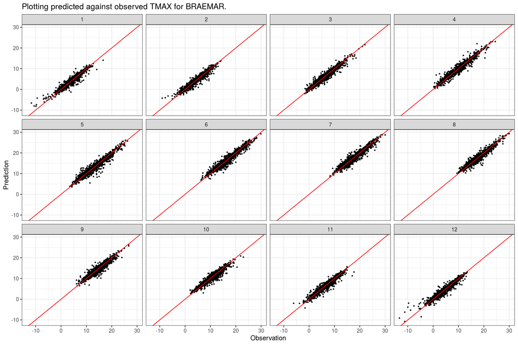

```r
data <- readRDS(file = "data/3_1_data.rds")

# station of interest, the dependent variable of the linear model
station <- "BRAEMAR"
# covariates for the linear model
covariates <- c(
  "BALMORAL", "ARDTALNAIG", "FASKALLY",
  "LEUCHARS", "PENICUIK", "`ROYAL BOTANICAL GARDEN`",
  "BENMORE"
)

# Plot all prediction against actual values
plot_actual_pred(data, station, covariates)
```

We can see from the figure above that for all of the months we have a concentration of points on the $y=x$ line. This suggests that the linear models are producing good estimates of the daily $\text{TMAX}$ for the BRAEMAR weather station for each month where there does not seem to be a difference between the months. However we will give a more detailed explanation when we look at the proper scores for each of the linear models for each month. The months are indicated by numbers where 1 = January, 2 = February, … , 12 = December. Furthermore, what is nice about these plots that not only they show us how well the model has predicted the values but also how the conglomeration of points moves throughout the months. We can see that for the winter months the points are close to colder $\text{TMAX}$ values while for the summer months the concentration of the points shifts upwards towards hotter temperatures.

We can take it one step further by producing a time series plot to compare the observed and predicted daily $\text{TMAX}$ values for BRAEMAR for a given year, in the hope that they follow a similar pattern. In this case I have plotted it for the year 1960, however we could have compared any other year. To do this I first created a separate linear model based on all the data for each month and then predicted the daily $\text{TMAX}$ values for day of 1960 using the respective model for each month. Then we plotted the predicted and observed daily $\text{TMAX}$ values for the given year, as seen below. This was done by using the $\textit{plot_year_pred_actual()}$ function.

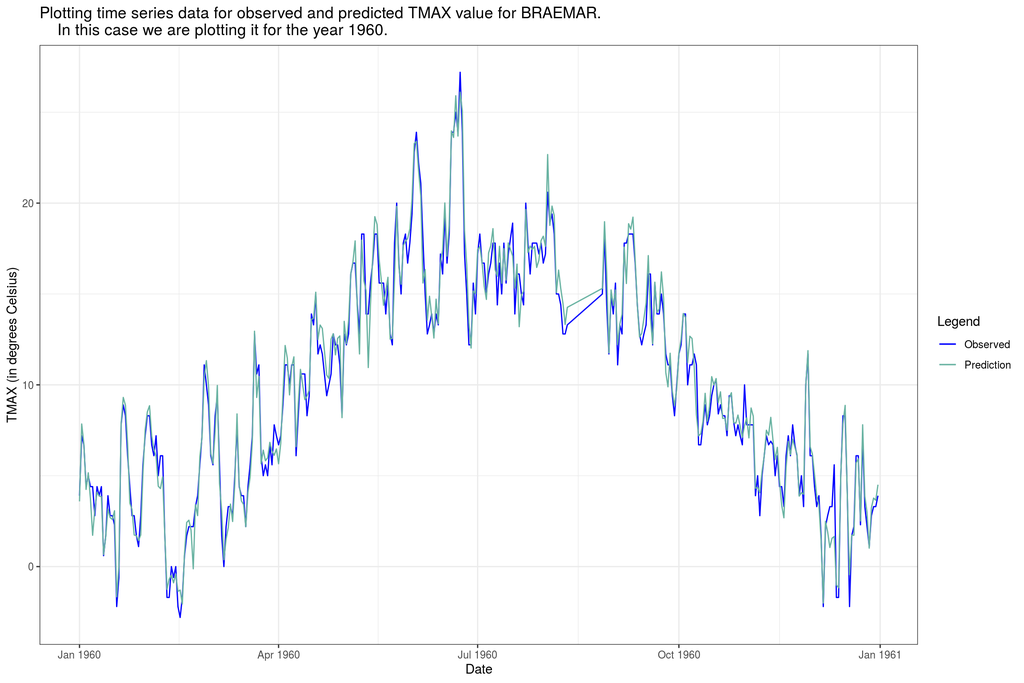

```r
data <- readRDS(file = "data/3_1_data.rds")

# station of interest, the dependent variable of the linear model
station <- "BRAEMAR"
# covariates for the linear model
covariates <- c(
  "BALMORAL", "ARDTALNAIG", "FASKALLY",
  "LEUCHARS", "PENICUIK", "`ROYAL BOTANICAL GARDEN`",
  "BENMORE"
)

# Plot all prediction against actual values for a given year time series plot
plot_year_pred_actual(data, 1960, station, covariates)
```

From the plot above we can see that the linear model predictions for the daily $\text{TMAX}$ values closely fit the observed values of $\text{TMAX}$ for 1960, for all months. Again this shows us that the linear model for each month does in fact predict well, we will further look into this when looking at the proper scores, in the next section. Furthermore, this highlights the power of using a linear model for each month since we can clearly see the seasonal trend where the summer months have higher $\text{TMAX}$ values than the winter months.

We will now take a step further and look at our linear models in depth. In particular, we are interested in the coefficient of each of the covariates, this is because, they will in fact indicate which stations have more predictive power for BRAEMAR. This is because if one of the other stations has a larger coefficient this means that they have more influence on the estimate of the linear model. Below I have extracted the coefficients for each of the covariates (other weather stations) for each month.

```r
# Read in data used to calculate the coefficients of the model
data_coeff <- readRDS(file = "data/3_1_data_coeff.rds")

names(data_coeff)[7] <- "ROYAL_BOTANICAL_GARDEN"

# Calculate coefficients of the models
knitr::kable(data_coeff, digits = 4)
```

| Month | BALMORAL | ARDTALNAIG | FASKALLY | LEUCHARS | PENICUIK | ROYAL_BOTANICAL_GARDEN | BENMORE |
| --- | --- | --- | --- | --- | --- | --- | --- |
| 1 | 0.6073 | 0.1979 | 0.0884 | 0.0631 | 0.0653 | -0.0842 | 0.0574 |
| 2 | 0.7298 | 0.1149 | 0.1142 | 0.0034 | 0.1660 | -0.1625 | 0.0120 |
| 3 | 0.6750 | 0.1503 | 0.1833 | -0.1288 | 0.1136 | -0.0242 | 0.0307 |
| 4 | 0.6753 | 0.1551 | 0.2414 | -0.1330 | 0.1123 | -0.0112 | -0.0466 |
| 5 | 0.6706 | 0.1440 | 0.2012 | -0.0918 | 0.0721 | -0.0069 | 0.0341 |
| 6 | 0.6576 | 0.2172 | 0.2082 | -0.0782 | 0.0490 | -0.0322 | -0.0008 |
| 7 | 0.6014 | 0.2013 | 0.2342 | -0.0514 | 0.1000 | -0.0668 | -0.0019 |
| 8 | 0.6200 | 0.1584 | 0.2681 | -0.0927 | 0.0510 | -0.0073 | 0.0286 |
| 9 | 0.7222 | 0.1762 | 0.2042 | -0.0881 | 0.1019 | -0.0911 | 0.0106 |
| 10 | 0.6424 | 0.0992 | 0.1824 | -0.0225 | 0.2427 | -0.1862 | 0.0594 |
| 11 | 0.5815 | 0.1277 | 0.0550 | 0.0890 | 0.1680 | -0.0900 | 0.0775 |
| 12 | 0.5475 | 0.1378 | 0.1396 | 0.0534 | 0.0591 | 0.0380 | 0.0175 |

We have now identified four groups of stations, we now need to explain why some stations have better predictive power than others. To do this we will begin by analyzing the spatial location of these weather stations. To do this we will begin by visualizing the relative position of BRAMEAR with respect to the other stations.

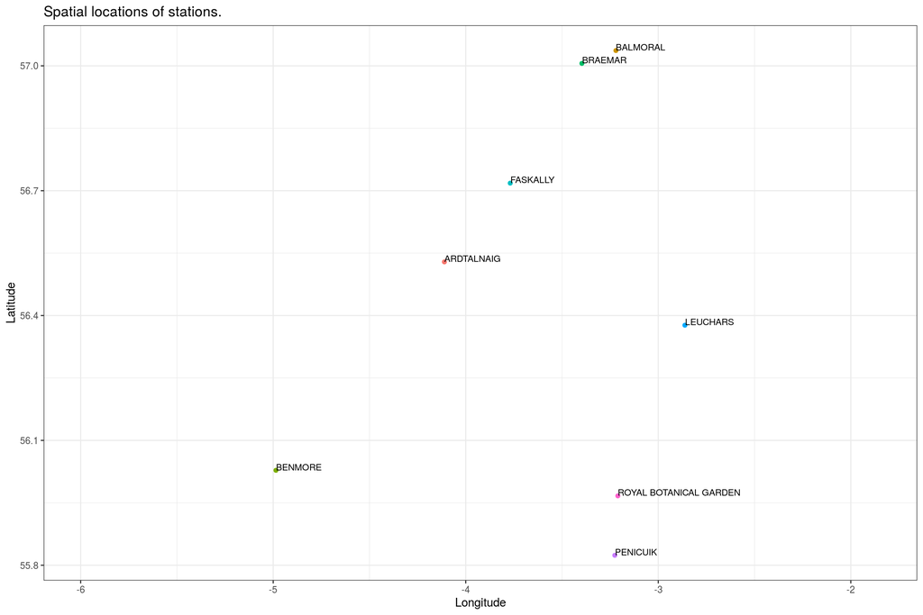

```r
# Plot the spatial locations of the stations
plot_locations(ghcnd_stations)
```

1. Why does PENICUIK have positive coefficient values despite it being the station which is furthest away?
2. Why does LEUCHARS have small coefficient values, despite it being close to ARDTALNAIG and FASKALLY which both have large coefficients with respect to LEUCHARS?

To answer these question we can search for solutions in the elevation of the stations.

```r
# get elevations from ghcnd_stations
elevations <- ghcnd_stations %>% select(c(Name, Elevation))

knitr::kable(elevations, digits = 4)
```

| Name | Elevation |
| --- | --- |
| BRAEMAR | 339 |
| BALMORAL | 283 |
| ARDTALNAIG | 130 |
| FASKALLY | 94 |
| LEUCHARS | 10 |
| PENICUIK | 185 |
| ROYAL BOTANICAL GARDEN | 26 |
| BENMORE | 12 |

From the table above we can see that the elevation of BRAMEAR is the highest at an elevation of 339m followed by BALMORAL at 283m and then PENICUIK at 185m. This in fact can explain why, even though PENICUIK is so far way from BRAMEAR, it had large coefficient values in the linear model, since it had a high elevation. Again, we can see that the stations with the lowest elevation in fact had the lowest coefficient values, and in some cases negative indicating therefore indicating an inverse relation between them. In fact the stations which have negative coefficients are LEUCHARS, ROYAL BOTANICAL GARDEN and BENMORE which have lowest elevations. Furthermore this also explains why LEUCHARS which is in a similar distance to BRAMEAR as ARDTALNAIG and FASKALLY had small coefficient values. This is because LEUCHARS has the smallest elevation of 10m thus it does not have much predictive power despite it being close to BRAMEAR.

This suggests that stations which are close and have a similar elevation to BRAMEAR had more predictive power. Therefore, the spatial location and elevation are fundamental in determining the coefficients of the linear models. Which means that stations which are similar geographically to BRAMEAR have more predictive power. This explains why for example BALMORAL has large positive coefficient values since it is geographically very similar to BRAMEAR in terms of location and elevation. Thus, as the independent variable increases (BALMORAL), that is the $\text{TMAX}$ for this station, then we would also expect the dependent variable to increases (BRAMEAR), daily $\text{TMAX}$ for BRAMEAR.

The last thing I would like to mention is the precipitation at BRAMEAR. By doing some more investigation in particular by using the following website https://en.climate-data.org/europe/united-kingdom/scotland/braemar-29849/ I found that the level of precipitation at this station is constant with an expected 11-14 days of rain per month. As a result, if we could include a precipitation value to predict daily $\text{TMAX}$ scores perhaps we could have better predictions for our models since we would be incorporating a key ingredient to predict temperatures.

## 3.2 Assessment

Finally, in this section we will see how assess how well each linear model predicts daily $\text{TMAX}$ for BRAMEAR. To do this we will calculate the expected Absolute Error and Dawid-Sebastiani scores.

Before we show the results we need to understand what each of these scores are telling us. First of all both of these scores are $\textit{negatively oriented}$ meaning that smaller values for the scores means that the models are better at predicting. Therefore, we aim to have the smallest values for the proper scores for each of our models. In this case, $F$ is the predictive distribution.

In particular the Absolute Error is given by:
$$S_{AE}(F, y) = |y − \hat{y}_F |, \text{ where } \hat{y}_F \text{ is a point estimate under } F, \text{ e.g. the
median } F^{−1}(1/2).$$
And the Dawid-Sebastiani score is given by:
$$S_{DS}(F, y) = \frac{(y-\mu_F)^2}{\sigma^2_F} + 2log(\sigma^2_F), \text{ where } \mu_F \text{ is the mean estimate under } F, \text{ and } \sigma^2_F \text{ is the estimated prediction standard deviation }.$$
Furthermore, the Absolute Error only involves the point prediction and not the uncertainty about the prediction. That means it cares about how close the predictions match to the observed data. In contrast to the Dawid-Sebastiani score which includes the uncertainty through the use of the estimated prediction standard deviation. Therefore, if the Dawid-Sebastiani score is large this means that estimated prediction standard deviation is too large or too small, compared with the difference between the prediction and observed value.

In this case since we are interested in calculating the expected scores and given the fact that we have a collection of forecast/prediction distributions $\{F_i\}$, each predicting a single observation from the collection $\{y_i\}$. Therefore, we have a collection of prediction/observation pairs $\{(F_i, y_i)\}$. That means that the median $\hat{y}_F$ for the Absolute Error will be in fact the prediction $F_i$ for the observation $y_i$. Likewise, the mean $\mu_F$ for the Dawid-Sebastiani will also be the prediction $F_i$ for the observation $y_i$ and where the $\sigma^2_F$ will be the estimated prediction standard deviation. Notice that the Absolute Error will have the same units as the data while the Dawid-Sebastiani is unitless, so we cannot compare them directly.

As a result, this means that we will be finding the average for all of these the prediction/observation pairs $\{(F_i, y_i)\}$, for a given proper score, that is:

$$\hat{S}_{Proper Score}(\{F_i, y_i\}) = \frac{1}{N}\sum_{i=1}^N S_{Proper Score}(F_i, y_i)$$
We calculate this value for each of the 10 cross-validations and then find the mean proper score over all the cross-validations to end up with one final score for each month. To do this we make use of the $\textit{calculate_proper_scores()}$ function. Below are the scores for each of the months with the associated standard deviation in the scores.

```r
proper_scores <- readRDS(file = "data/3_2_proper_scores.rds")

knitr::kable(proper_scores, digits = 4)
```

| Month | Absolute_Error | Std_Dev_AE | Dawid_Sebastiani | Std_Dev_DS | Difference |
| --- | --- | --- | --- | --- | --- |
| 1 | 0.6331 | 0.0518 | 0.8542 | 0.2043 | 0.2211 |
| 2 | 0.6359 | 0.0446 | 0.7923 | 0.1707 | 0.1564 |
| 3 | 0.6449 | 0.0467 | 0.7739 | 0.1687 | 0.1291 |
| 4 | 0.6834 | 0.0264 | 0.9308 | 0.2375 | 0.2474 |
| 5 | 0.7527 | 0.0595 | 1.1411 | 0.2176 | 0.3884 |
| 6 | 0.7397 | 0.0558 | 1.0144 | 0.1033 | 0.2747 |
| 7 | 0.7358 | 0.0569 | 0.9974 | 0.1607 | 0.2616 |
| 8 | 0.6656 | 0.0635 | 0.8119 | 0.2484 | 0.1463 |
| 9 | 0.7014 | 0.0413 | 0.9498 | 0.1372 | 0.2484 |
| 10 | 0.6374 | 0.0465 | 0.7957 | 0.1286 | 0.1583 |
| 11 | 0.6232 | 0.0353 | 0.7831 | 0.1319 | 0.1600 |
| 12 | 0.6335 | 0.0417 | 0.8923 | 0.1596 | 0.2588 |

We will begin by analyzing the Absolute Error. We can see that for all the months the absolute error ranges from 0.63 to 0.75. Furthermore, the standard deviation of these scores are also very small, suggesting that we have accurate results. However, we need to understand what this in fact means. Recall, that the Absolute Error measures the distance between the observation and prediction, so it is measured in degrees celcius and since all the absolute errors are below 1, our models are all quite accurate. We can see that the difference between the scores in fact does not vary by much which suggests that there is no month which is considerably harder to predict than other months. Due to the magnitude of the differences between the scores across all months. However, we can see that as the move towards warmer months the Absolute error score does increase in particular for May, June and July, suggesting that perhaps the models find it slightly harder to predict the $\text{TMAX}$ for these months. Please note that this increase is still small even when compared to the colder months.

We can now look at the Dawid-Sebastianis scores. We can see that the values range from 0.77 to 1.14, again there is not a large difference smallest and largest value. Furthermore, the standard deviation of these scores are small, suggesting good estimates for these scores, however when we compare these to the Absolute Error standard deviation they are in fact considerably larger. We can see however, that the hotter months, May, June and July again have higher Dawid-Sebastianis scores suggesting that these are in fact harder to predict than the other months. Notice that the Dawid-Sebastianis can be large if the predictions are far from the observed point. As a result, this can be explained using the Absolute Error. We can see that for these month we have large values for the Absolute Error which in turn can explain why we see a large value for the Dawid-Sebastianis scores, since the Absolute Errors between the scores are in fact far away.

We can take it one step further and see how the coefficient of the linear models vary with the proper scores of the months. As we have seen before the coefficient of each station seems to be consistent throughout all the months, which means that the linear models for each month are similar. As a result, since the Dawid-Sebastianis and Absolute Error both increase for the hotter months, in particular May, June and July. This means that, since the linear models are in fact similar across the months, the models have difficulties when trying to predict hotter months.

Below we have plotted the proper scores against the month to visualize the data easier. I have chosen to plot them on different axis due to the fact that they do not have the same units.

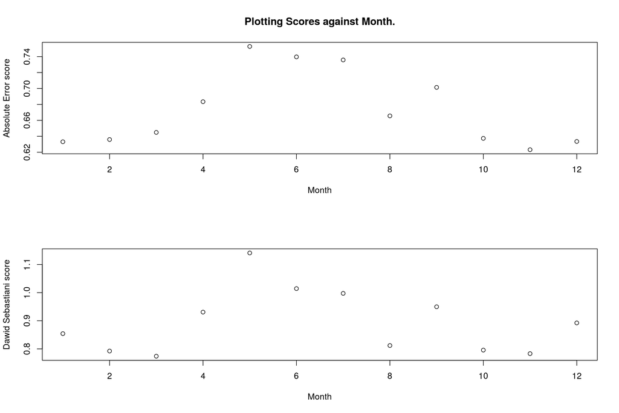

```r
plot_proper_scores(proper_scores)
```

In fact from the graph we can see that the Dawid-Sebastianis and Absolute Error scores follow a parabolic shape, where the peaks are at the summer months. Again, this is consistent with the discussion from above. Furthermore, with this visualization we in fact see other months which have similar Dawid-Sebastianis scores to the hotter months, that is May, June and July. In particular, April and September where the Dawid-Sebastianis scores are above 0.9. This is also consistent with the Absolute Error score are also large. This suggests that for these months they are also difficult to predict in comparison to the winter months. To be concrete, we can see that both the Dawid-Sebastianis and Absolute Error proper score increase in the hotter months, May, June and July, and then decrease in the winter months, suggesting that prediction models find it harder to predict the hotter months.

Furthermore, we can see that both scores are correlated, when one increase the other does too, but to what extent? To show this relation between the two scores we have calculated the difference between them, that is the Dawid-Sebastiani - Absolute Error, we can now use this value to talk about these scores together. When we see a large difference between the scores this suggests that either the Dawid-Sebastiani is large or the Absolute Error is small. Recall that, the Dawid-Sebastianis measures if the models prediction uncertainty is appropriate or not. Therefore, the reasons for a high Dawid-Sebastianis could be because the models do not take into account the uncertainty of the prediction well.

Take for example the months of May and June which have similar absolute errors are given by 0.7527 and 0.7397  
respectively. However, the difference between the scores for each month are noticeable, in particular we have 0.3884 and 0.2747. Since the Absolute errors are relatively similar for both months, then the rise in difference must be due to the Dawid-Sebastiani scores. Since the point estimate predictions have similar error, this is known by the Absolute Error. Therefore, in the model for May, it must be the case that prediction residual standard deviation differs from the prediction standard deviation more than for June. This means that May has more uncertainty than June, in turn we can conclude that the model for June is better than the model for May. This example particularly highlights the power of the Dawid-Sebastiani score. Since we can see that even though two models seem to be preforming the same with the Absolute Error score the Dawid-Sebastiani score gives us more information about the uncertainty with regards to the predictions.

As a result, we can see form the table that the months with the largest difference are in fact the warmer, summer months, again this suggests that these months are harder to predict with the linear model with respect to the winter months.

To conclude, in this section we have managed to make separate linear models for each month for the BRAMEAR to predict the daily $\text{TMAX}$. We analyzed the coefficients of the models to see which stations had more predictive power and we saw that stations that where geographically similar to the station we are trying to predict had more predictive power. We then assessed how well these linear models where for each moths by using two different scores. We concluded that the summer months where in fact harder to predict than the winter months by analyzing the values of the Absolute Error and Dawid-Sebastiani score for each linear model.

# 4 Code appendix

## 4.1 Function definitions

```r
# Lorenzo Stigliano (s1725018, LorenzoStigliano)

suppressPackageStartupMessages(library(StatCompLab))
suppressPackageStartupMessages(library(dplyr))
suppressPackageStartupMessages(library(ggplot2))
suppressPackageStartupMessages(library(tidyr))

# Set the seed so we can have consistent results.
set.seed(123)

############################## Question 2.1 ####################################

monthly_trends <- function(data) {
  #' Getting Monthly Trends per weather station
  #'
  #' Here we are getting the monthly trends for the each of the months and for
  #' each of the different stations. This is used to find the  long-term temporal
  #' trend in TMIN for each month, for each weather station.
  #'
  #' @param data (data frame) a data frame with the following columns:
  #' 1 - ID: ID of the station (chr)
  #' 2 - Name: Name of the station (chr)
  #' 3 - Month: Month of the year 1-12 (int)
  #' 4 - Year: Year of the measurement (int)
  #' 5 - TMIN: Average TMIN for a specific year and month (dbl)
  #'
  #' @return coeff_data (dataframe) a data frame with the following columns:
  #' 1 - Name: Name of the station (chr)
  #' 2 - ID: ID of the station (chr)
  #' 3 - Month: Month of the year 1-12 (int)
  #' 4 - Coeff: 10*Coefficient of the linear model for the given station and
  #'            month such that it shows us the change per decade of the
  #'            temperatures. (dbl)
  #' 5 - Intercept: Intercept of the linear model for the given station
  #'                and month (dbl)
  #' 6 - Lower_Bound: Lower bound on the credible interval for Coeff (dbl)
  #' 7 - Upper_Bound: Upper bound on the credible interval for Coeff (dbl)

  # Create an empty data frame to store the values
  coeff_data <- data.frame()

  # Iterate over the stations
  for (j in c(1:8)) {

    # Get the station ID
    id <- ghcnd_stations[j, 1]
    # Get the station names
    name <- ghcnd_stations[j, 2]

    # Iterate over the months
    for (i in c(1:12)) {

      # Get the data for the given month and station
      month_data <- filter(data, data$Month == i, ID == id)
      # Create a linear model where we are trying to fit TMIN against year
      fit0 <- lm(TMIN ~ 1 + Year, data = month_data)

      # Extract the information form the linear model that we created
      # Get the coefficient
      coeff <- coef(fit0)["Year"]
      # Get the intercept
      intercept <- coef(fit0)["(Intercept)"]
      # Calculate the standard error for the coefficient such that we can plot
      # credible intervals for this value
      std_error <- sqrt(vcov(fit0)["Year", "Year"])

      # Calculate the credible bounds on the coefficient
      bound <- coeff - std_error * qnorm(c(1 - 0.05 / 2, 0.05 / 2))

      # Add the new row to the data frame
      coeff_data <- rbind(coeff_data, data.frame(
        Name = name, ID = id,
        Month = i, Coeff = coeff * 10,
        Intercept = intercept,
        Lower_Bound = bound[1] * 10,
        Upper_Bound = bound[2] * 10
      ))
    }
  }

  # Get rid of the row names
  rownames(coeff_data) <- NULL
  # Return the data frame
  return(coeff_data)
}

plot_coeff <- function(coeff_data) {
  #' Plot the “change per decade” for each month and each weather station
  #' it uses the output from the monthly_trends functions to plot this table
  #'
  #' @param coeff_data (data frame) this is in fact the output from the monthly_trends()
  #' function, has the following columns:
  #' 1 - Name: Name of the station (chr)
  #' 2 - ID: ID of the station (chr)
  #' 3 - Month: Month of the year 1-12 (int)
  #' 4 - Coeff: 10*Coefficient of the linear model for the given station and
  #'            month such that it shows us the change per decade of the
  #'            temperatures. (dbl)
  #' 5 - Intercept: Intercept of the linear model for the given station
  #'                and month (dbl)
  #' 6 - Lower_Bound: Lower bound on the credible interval for Coeff (dbl)
  #' 7 - Upper_Bound: Upper bound on the credible interval for Coeff (dbl)
  #'
  #' @return a plot of the monthly trends for each station

  # Feed in ceoff_data
  coeff_data %>%
    # Group by name Id and month
    group_by(ID, Name, Month) %>%
    # Summarize the coeff such that it can be use later
    summarise(Coeff = Coeff, .groups = "drop") %>%
    # Plot Month against Coeff and separate on the Name of the station
    ggplot(aes(Month, Coeff, colour = Name)) +
    # Plot the points
    geom_point() +
    # Add the credible intervals on each of the Coeffs
    geom_ribbon(aes(y = Coeff, ymin = L, ymax = U),
      data = coeff_data %>%
        group_by(ID, Name, Month) %>%
        summarise(
          Coeff = Coeff,
          L = Lower_Bound,
          U = Upper_Bound, .groups = "drop"
        ),
      alpha = 0.25
    ) +
    # Facet_wrap on Name to produce multiple plots for each of the weather station
    facet_wrap(~Name) +
    ggtitle("Tempeature change per decade for each month and for each weather station.")
}

############################## Question 2.2 ####################################

randomisation_test <- function(data_residuals, J) {
  #' Preforms a randomization tests on the residuals for each month for a chosen
  #' station
  #'
  #' @param data_residuals (data frame) a data frame for a given station
  #' with the following columns:
  #' 1 - Day: Day of the month measurements taken (int)
  #' 2 - Month: Month of the year 1-12 (int)
  #' 3 - Year: Year of the measurement (int)
  #' 4 - R: Residual for the particular day, calculated by: TMIN - mean(TMIN) (for
  #' the given month in which the measurement was taken) (dbl)
  #' @param J (int) this is the number of permutations to be carried out
  #'
  #' @return p_values_all (data frame) containing p-value for each month with the
  #' following columns:
  #' 1 - Month: Month of the year 1-12 (int)
  #' 2 - Month_Residuals_Var: Residual Variance for each month (dbl)
  #' 3 - One_Sided_P_Value: P-value for the associated month (dbl)
  #' 4 - Two_Sided_P_Value: P-value for the associated month for
  #' the two sided test (dbl)
```

```r
  # Variance of all residuals, under H_0
  Var_all <- (data_residuals %>%
    summarise(Var_R = var(R), .groups = "drop"))$Var_R

  # T statistics for all months
  T_stats_months <- data_residuals %>%
    group_by(Month) %>%
    summarise(T_stats = var(R) - Var_all, .groups = "drop")

  # Residuals for each month
  Variances_Residual_Monthly <- data_residuals %>%
    group_by(Month) %>%
    summarise(Variance = var(R), .groups = "drop")


  # This variable keeps tract of all the permutations greater than the test
  # statistic for each month, used for the one-sided test
  Ts_count <- numeric(12)

  # Run for the number of iterations J
  for (j in c(1:J)) {

    # Mutate the data by moving position of the residuals for each month
    # And then calculate the T_sample for this permutation
    permutation <- data_residuals %>%
      # mutate the R column so all months have some permutation of the original
      # residuals
      mutate(R = sample(R, size = n(), replace = FALSE)) %>%
      group_by(Month) %>%
      # Create test statistic for this permutation by using the residual for each month
      summarize(T_sample = var(R) - Var_all)

    # Check if the permutation is greater than the test statistic for each month
    Ts_count <- Ts_count + c(as.numeric(permutation$T_sample >= T_stats_months$T_stats))
  }
  # calculate the p value, proportion of the permutations that give
  # a test stat at least as extreme as the one we observed

  # Calculate the p value for each month, since we already have the number of
  # permutations which are greater that the test statistic all we are left to do
  # is find the mean which in this case is just divided by the over all number
  # of permutations we have done
  pvalues <- Ts_count / J

  # Create a data frame for all the p-values for each month we have done the
  # randomization test for
  p_values_all <- data.frame(
    Month = seq_len(12),
    Month_Residuals_Var = Variances_Residual_Monthly$Variance,
    P_Value_One_Sided = pvalues,
    P_Value_Two_Sided = 2 * apply(cbind(pvalues, 1 - pvalues),
      1,
      FUN = min
    )
  )

  return(p_values_all)
}

############################## Question 3.1 ####################################

model_station <- function(data_fit, station, covariates) {
  #' Function to find model for given data for a station
  #'
  #' Note: the data_fit parameter needs to be in a particular form. In particular
  #' the covariates list needs to have the same values as the columns of the
  #' data_fit data frame we want to create our linear model on.
  #'
  #' @param data_fit (data frame) a data frame with the following columns:
  #' 1 - Date: This is a new parameter where it just puts the Day, Year and Month
  #' together (date)
  #' 2 - Day: Day of the month measurements taken (int)
  #' 3 - Month: Month of the year 1-12 (int)
  #' 4 - Year: Year of the measurement (int)
  #' 5 - BRAEMAR: These are the TMAX for the corresponding day for BRAEMAR
  #' 6 - BALMORAL: These are the TMAX for the corresponding day for BALMORAL
  #' 7 - ARDTALNAIG: These are the TMAX for the corresponding day for ARDTALNAIG
  #' 8 - FASKALLY: These are the TMAX for the corresponding day for FASKALLY
  #' 9 - LEUCHARS: These are the TMAX for the corresponding day for LEUCHARS
  #' 10 - PENICUIK: These are the TMAX for the corresponding day for PENICUIK
  #' 11 - `ROYAL BOTANICAL GARDEN`: These are the TMAX for the corresponding
  #' day for ROYAL BOTANICAL GARDEN
  #' 12 - BENMORE: These are the TMAX for the corresponding day for BENMORE
  #' @param station (str) this is the name of the station that we want to do our
  #' linear model on, the dependent variable
  #' @param covariates (list of str) this is the name of the other stations as the
  #' covariates that we can use as our linear model, these need to be the same as
  #' the column names of the data_fit data frame.
  #'
  #' @return the linear model with the other stations as covariates

  # Create the formula used for the linear model
  formula <- as.formula(
    paste(station,
      paste(covariates, collapse = " + "),
      sep = " ~ "
    )
  )

  # Create the linear model
  model <- lm(formula, data = data_fit)

  return(model)
}

predict_station <- function(model, data_pred) {
  #' Function to find prediction for given data
  #' Note: the data_pred parameter needs to be in a particular form.
  #'
  #' @param model (linear model produced by lm()) this is the linear model made by
  #' the model_station() function
  #' @param data_pred (data frame) a data frame with the following columns:
  #' 1 - Date: This is a new parameter where it just puts the Day, Year and Month
  #' together (date)
  #' 2 - Day: Day of the month measurements taken (int)
  #' 3 - Month: Month of the year 1-12 (int)
  #' 4 - Year: Year of the measurement (int)
  #' 5 - BRAEMAR: These are the TMAX for the corresponding day for BRAEMAR
  #' 6 - BALMORAL: These are the TMAX for the corresponding day for BALMORAL
  #' 7 - ARDTALNAIG: These are the TMAX for the corresponding day for ARDTALNAIG
  #' 8 - FASKALLY: These are the TMAX for the corresponding day for FASKALLY
  #' 9 - LEUCHARS: These are the TMAX for the corresponding day for LEUCHARS
  #' 10 - PENICUIK: These are the TMAX for the corresponding day for PENICUIK
  #' 11 - `ROYAL BOTANICAL GARDEN`: These are the TMAX for the corresponding
  #' day for ROYAL BOTANICAL GARDEN
  #' 12 - BENMORE: These are the TMAX for the corresponding day for BENMORE
  #'
  #' @return the prediction for the data_pred and model passed to this function

  predict(model, newdata = data_pred, se.fit = TRUE)
}

get_model_coeff <- function(data, station, covariates) {
  #' Calculates the linear model for a given station for each month and extracts the
  #' coefficients of each of the covariates.
  #'
  #' Note: the data parameter needs to be in a particular form. Where the covariates
  #' parameter must have the same column names for this function to work.
  #'
  #' @param data (data frame) a data frame with the following columns, note that
  #' the name of the columns can be changed but need to also change @param covariates.
  #' 1 - Date: This is a new parameter where it just puts the Day, Year and Month
  #' together (date)
  #' 2 - Day: Day of the month measurements taken (int)
  #' 3 - Month: Month of the year 1-12 (int)
  #' 4 - Year: Year of the measurement (int)
  #' 5 - BRAEMAR: These are the TMAX for the corresponding day for BRAEMAR (dbl)
  #' 6 - BALMORAL: These are the TMAX for the corresponding day for BALMORAL (dbl)
  #' 7 - ARDTALNAIG: These are the TMAX for the corresponding day for ARDTALNAIG (dbl)
  #' 8 - FASKALLY: These are the TMAX for the corresponding day for FASKALLY (dbl)
  #' 9 - LEUCHARS: These are the TMAX for the corresponding day for LEUCHARS (dbl)
  #' 10 - PENICUIK: These are the TMAX for the corresponding day for PENICUIK (dbl)
  #' 11 - `ROYAL BOTANICAL GARDEN`: These are the TMAX for the corresponding
  #' day for ROYAL BOTANICAL GARDEN (dbl)
  #' 12 - BENMORE: These are the TMAX for the corresponding day for BENMORE (dbl)
  #' @param station (str) this is the name of the station that we want to do our
  #' linear model on, the dependent variable
  #' @param covariates (list of str) this is the name of the other stations as the
  #' covariates that we can use as our linear model, these need to be the same as
  #' the column names of the @param data.
  #'
  #' @return output_data (data frame) with the coefficients of each station for
  #' each month. It has the following columns:
  #' 1 - Month: Month of the year 1-12 (int)
  #' 2 - 8: Are the stations with their associated coeffcient as the entries.
```

```r
  # Create an empty data frame to add the information from the linear model
  output_data <- data.frame()

  # iterate over all the months
  for (i in seq_len(12)) {
    # get the data to use for the model by separating by month
    data_fit <- data %>% filter(Month == i)
    # find the model for the given data for the station of choice
    mod <- model_station(data_fit, station, covariates)
    # Extract the coefficients
    coeff <- summary(mod)$coefficients
    # Add the coefficient for each of the covariantes to a new data frame
    # There will always be 7 covariate since we use all the other stations as
    # the covariates
    data_frame_month <- data.frame(
      Month = i,
      Station_1 = coeff[covariates[1], "Estimate"],
      Station_2 = coeff[covariates[2], "Estimate"],
      Station_3 = coeff[covariates[3], "Estimate"],
      Station_4 = coeff[covariates[4], "Estimate"],
      Station_5 = coeff[covariates[5], "Estimate"],
      Station_6 = coeff[covariates[6], "Estimate"],
      Station_7 = coeff[covariates[7], "Estimate"]
    )

    # Add this data data_frame_month to data_all
    output_data <- rbind(output_data, data_frame_month)
  }
  # Rename the name of the station to the name used in covariates
  colnames(output_data) <- c("Month", covariates)

  # Return output_data, which is all the information we need
  return(output_data)
}

plot_actual_pred <- function(data, station, covariates) {
  #' This function plots the predicted value of TMAX for a given station against
  #' the observation for TMAX for a given station Using the linear model created by the
  #' function model_station. These plots are called prediction v observation plots.
  #'
  #' @param data (data frame) a data frame with the following columns, note that
  #' the name of the columns can be changed but need to also change @param covariates.
  #' 1 - Date: This is a new parameter where it just puts the Day, Year and Month
  #' together (date)
  #' 2 - Day: Day of the month measurements taken (int)
  #' 3 - Month: Month of the year 1-12 (int)
  #' 4 - Year: Year of the measurement (int)
  #' 5 - BRAEMAR: These are the TMAX for the corresponding day for BRAEMAR (dbl)
  #' 6 - BALMORAL: These are the TMAX for the corresponding day for BALMORAL (dbl)
  #' 7 - ARDTALNAIG: These are the TMAX for the corresponding day for ARDTALNAIG (dbl)
  #' 8 - FASKALLY: These are the TMAX for the corresponding day for FASKALLY (dbl)
  #' 9 - LEUCHARS: These are the TMAX for the corresponding day for LEUCHARS (dbl)
  #' 10 - PENICUIK: These are the TMAX for the corresponding day for PENICUIK (dbl)
  #' 11 - `ROYAL BOTANICAL GARDEN`: These are the TMAX for the corresponding
  #' day for ROYAL BOTANICAL GARDEN (dbl)
  #' 12 - BENMORE: These are the TMAX for the corresponding day for BENMORE (dbl)
  #' @param station (str) this is the name of the station that we want to do our
  #' linear model on, the dependent variable
  #' @param covariates (list of str) this is the name of the other stations as the
  #' covariates that we can use as our linear model, these need to be the same as
  #' the column names of the data_fit data frame.
  #'
  #' @return the a plot for prediction against actual value for TMAX for each month
  #' where the plot are labeled by the number of the month.

  # Create an empty data frame to add the actual values and prediction for each of
  # the months from the linear model
  data_all <- data.frame()

  # Iterate over the month
  for (i in seq_len(12)) {

    # get the data to use for the model by separating by month
    data_fit <- data %>% filter(Month == i)
    # find the model for the given data for the given station
    mod <- model_station(data_fit, station, covariates)
    # find the predictions for TMAX for the given data for the given station
    # using the above model
    pred <- predict_station(mod, data_fit)

    # Add the actual and prediction values for TMAX for each month
    data_frame_month <- data.frame(
      Observation = pull(data_fit, station),
      Prediction = pred$fit,
      Month = numeric(length(pred$fit)) + i
    )

    # Add data_frame_month to data_all so we can plot them later
    data_all <- rbind(data_all, data_frame_month)
  }
  # Update name of the first column to observed
  names(data_all)[1] <- "Observation"

  # Plot all the actual values against predicted values for all months
  ggplot(data_all) +
    geom_point(aes(Observation, Prediction), size = 0.5) +
    # Add the line y = x to show good prediction
    geom_abline(intercept = 0, slope = 1, col = "red") +
    facet_wrap(~Month) +
    ggtitle(sprintf("Plotting predicted against observed TMAX for %s.", station))
}

plot_year_pred_actual <- function(data, year, station, covariates) {
  #' This function plots the predicted value of TMAX for a given station and
  #' the observation for TMAX for a given station for a given year.
  #' Using the linear model created by the function model_station.
  #' These plots are a time series plot to see how the prediction and observation
  #' matches for a year
  #'
  #' @param data (data frame) a data frame with the following columns, note that
  #' the name of the columns can be changed but need to also change @param covariates.
  #' 1 - Date: This is a new parameter where it just puts the Day, Year and Month
  #' together (date)
  #' 2 - Day: Day of the month measurements taken (int)
  #' 3 - Month: Month of the year 1-12 (int)
  #' 4 - Year: Year of the measurement (int)
  #' 5 - BRAEMAR: These are the TMAX for the corresponding day for BRAEMAR (dbl)
  #' 6 - BALMORAL: These are the TMAX for the corresponding day for BALMORAL (dbl)
  #' 7 - ARDTALNAIG: These are the TMAX for the corresponding day for ARDTALNAIG (dbl)
  #' 8 - FASKALLY: These are the TMAX for the corresponding day for FASKALLY (dbl)
  #' 9 - LEUCHARS: These are the TMAX for the corresponding day for LEUCHARS (dbl)
  #' 10 - PENICUIK: These are the TMAX for the corresponding day for PENICUIK (dbl)
  #' 11 - `ROYAL BOTANICAL GARDEN`: These are the TMAX for the corresponding
  #' day for ROYAL BOTANICAL GARDEN (dbl)
  #' 12 - BENMORE: These are the TMAX for the corresponding day for BENMORE (dbl)
  #' @param year (int) the year we want to plot the time series data for between
  #' 1960 - 2018
  #' @param station (str) this is the name of the station that we want to do our
  #' linear model on
  #' @param covariates (list of str) this is the name of the other stations as the
  #' covariates that we can use as our linear model, these need to be the same as
  #' the column names of the data_fit data frame.
  #'
  #' @return the a line plot for predicted value of TMAX for BRAEMAR and
  #' the observation for TMAX for BRAEMAR for each day of given year.
```

```r
  # Create an empty data frame to add the actual values and prediction for each of
  # the months from the linear model
  output_data <- data.frame()

  # Iterate over the months
  for (i in seq_len(12)) {

    # get the data to use for the model by separating by month we use all the month
    # over all years to predict the model
    data_fit <- data %>% filter(Month == i)
    # Then we get the data for the year and month we are trying to predict
    data_year <- data_fit %>%
      filter(Month == i) %>%
      filter(Year == year)

    # find the model for the given data for a given station
    mod <- model_station(data_fit, station, covariates)
    # find the predictions for TMAX for the given data for the station using the above
    # model, in particular for a specific year
    pred <- predict_station(mod, data_year)

    # Add the information we need to plot time series data, in particular
    # we need to add the Date of the prediction
    data_frame_month <- data.frame(
      Observation = pull(data_year, station),
      Prediction = pred$fit,
      Month = numeric(length(pred$fit)) + i,
      Date = data_year$Date
    )
    # Add data_frame_month to output_data such that we can plot it
    output_data <- rbind(output_data, data_frame_month)
  }
  # Update name of the first column to observed
  names(output_data)[1] <- "Observation"

  # Produce a time series plot of actual and observed data against all the days of
  # a given year by using the data from output_data
  ggplot(output_data %>% group_by(Month), aes(Observation, Prediction)) +
    # plot the line graph for actual data
    geom_line(aes(Date, Observation, color = "blue")) +
    # plot the line graph for actual data
    geom_line(aes(Date, Prediction, color = "#69b3a2")) +
    labs(
      x = "Date",
      y = "TMAX (in degrees Celsius)"
    ) +
    # Add a Legend to the plot
    scale_color_identity(
      name = "Legend",
      breaks = c("blue", "#69b3a2"),
      labels = c("Observed", "Prediction"),
      guide = "legend"
    ) +
    ggtitle(sprintf("Plotting time series data for observed and predicted TMAX value for %s.
    In this case we are plotting it for the year %s.", station, year))
}

plot_locations <- function(ghcnd_stations) {
  #' Plots the geographical locations of the stations
  #'
  #' @param ghcnd_stations (data frame) a data frame with the following columns:
  #' 1 - ID: ID of the station (chr)
  #' 2 - Name: Name of the station (chr)
  #' 3 - Latitude: Latitude of the position of station (dbl)
  #' 4 - Longitude: Longitude of the position of station (dbl)
  #' 5 - Elevation: Elevation of the station (int)
  #'
  #' @return the position of the geographical positions of the stations on a graph

  # Create a ggplot of with the data
  ggplot(ghcnd_stations) +
    # Plot the points by Longitude and Latitude
    geom_point(aes(Longitude, Latitude, col = Name)) +
    # Add tags to the point so we know what station they belong to
    geom_text(aes(Longitude, Latitude, label = Name), hjust = 0, vjust = 0, size = 3) +
    # Change x and y axis such that it is more visible
    coord_cartesian(
      xlim = c(min(ghcnd_stations$Longitude) - 1, max(ghcnd_stations$Longitude) + 1),
      ylim = c(min(ghcnd_stations$Latitude), max(ghcnd_stations$Latitude))
    ) +
    ggtitle("Spatial locations of stations.") +
    # Get rid of the legend
    theme(legend.position = "none")
}

############################## Question 3.2 ####################################

calculate_proper_scores <- function(all_data, station, covariates) {
  #' This function calculates the proper scores, the expected Absolute Error and
  #' Dawid-Sebastiani scores for the TMAX predictions at the chosen station. It is
  #' done by doing a 10-fold randomized cross-validation for each month.
  #'
  #' @param all_data (data frame) a data frame with the following columns (note that
  #' the name of the columns can be changed but need to also change @param covariates
  #' since they need to be the same.)
  #' 1 - Date: This is a new parameter where it just puts the Day, Year and Month
  #' together (date)
  #' 2 - Day: Day of the month measurements taken (int)
  #' 3 - Month: Month of the year 1-12 (int)
  #' 4 - Year: Year of the measurement (int)
  #' 5 - BRAEMAR: These are the TMAX values for the corresponding day for BRAEMAR (dbl)
  #' 6 - BALMORAL: These are the TMAX values for the corresponding day for BALMORAL (dbl)
  #' 7 - ARDTALNAIG: These are the TMAX values for the corresponding day for ARDTALNAIG (dbl)
  #' 8 - FASKALLY: These are the TMAX values for the corresponding day for FASKALLY (dbl)
  #' 9 - LEUCHARS: These are the TMAX values for the corresponding day for LEUCHARS (dbl)
  #' 10 - PENICUIK: These are the TMAX values for the corresponding day for PENICUIK (dbl)
  #' 11 - `ROYAL BOTANICAL GARDEN`: These are the TMAX values for the corresponding
  #' day for ROYAL BOTANICAL GARDEN (dbl)
  #' 12 - BENMORE: These are the TMAX values for the corresponding day for BENMORE (dbl)
  #' @param station (str) this is the name of the station that we want to do our
  #' linear model on, the dependent variable
  #' @param covariates (list of str) this is the name of the other stations as the
  #' covariates that we can use as our linear model, these need to be the same as
  #' the column names of the all_data data frame.
  #'
  #' @return proper_score_data (data frame) returns the proper score data for
  #' TMAX predictions at the chosen station. In particular it has the following
  #' columns:
  #' 1 - Month: Month of the year 1-12 (int)
  #' 2 - Absolute_Error: Absolute Error proper score (dbl)
  #' 3 - Std_Dev_AE: Standard Deviation of the Absolute Error proper score (dbl)
  #' 4 - Dawid_Sebastiani: Dawid Sebastiani proper score (dbl)
  #' 5 - Std_Dev_DS: Standard Deviation of the Dawid Sebastiani proper score (dbl)
  #' 6 - Difference: Difference between the Dawid Sebastiani and Absolute Error
  #' calculated by: Dawid Sebastiani - Absolute Error (dbl)
```

```r
  # initialize empty vectors of size 12 to store the scores and standard deviation
  # for Absolute Error proper score
  all_scores_ae <- numeric(12)
  s_d_scores_ae <- numeric(12)

  # initialize empty vectors of size 12 to store the scores and standard deviation
  # for Dawid-Sebastiani proper score
  all_scores_ds <- numeric(12)
  s_d_scores_ds <- numeric(12)

  all_residual_variances <- numeric(12)
  all_prediction_variance <- numeric(12)

  # iterate over all the months
  for (i in seq_len(12)) {

    # Find the number of rows for a given month to be able to separate the data into
    # 10 groups
    n_rows <- nrow(all_data %>% filter(Month == i))

    # 'data' is the data used for the cross-validation
    data <-
      # we first filter 'all_data' to get the month we will be doing the linear
      # models with
      all_data %>%
      filter(Month == i) %>%
      # Mutate this data frame such that we add a new column called 'Group' which
      # defines subset of the data frame for each of the 10 cross validation
      mutate(
        Group = sample(seq_len(n_rows), size = n_rows, replace = FALSE),
        Group = (Group %% 10) + 1
      )

    # create two placeholder vectors to get the proper score of every iteration
    # of the cross validation, after the 10 fold validation we will find the mean
    # of these values to get an estimate of the proper_scores
    scores_ae <- numeric(10)
    scores_ds <- numeric(10)

    # Then loop over the partition groups, estimating the model by leaving the group
    # out, and then predicting and scoring predictions for the group.
    for (grp in seq_len(10)) {

      # We first filter out the rows which do not belong to the group we want to
      # validate on, which we will use to fit the models
      data_fit <- data %>% filter(Group != grp)
      # Get the remain rows which belong to the grp we will validate on
      data_pred <- data %>% filter(Group == grp)

      # create the linear model for the chosen 'station' by using model_station()
      mod <- model_station(data_fit, station, covariates)
      # create predictions on the data_pred data set using the model 'mod'
      pred <- predict(mod, newdata = data_pred, se.fit = TRUE)

      # add to the vector 'scores_ae' the Absolute Error proper score
      scores_ae[grp] <- mean(proper_score("ae", pull(data_pred, station),
        median = pred$fit
      ))

      # find standard deviation used for the Dawid-Sebastiani proper score
      sd_pred <- sqrt(pred$se.fit^2 + pred$residual.scale^2)
      # add to the vector 'scores_ds' the Dawid-Sebastiani proper score
      scores_ds[grp] <- mean(proper_score("ds", pull(data_pred, station),
        mean = pred$fit,
        sd = sd_pred
      ))
    }
    # add the estimate of the Absolute Error proper score for the month
    all_scores_ae[i] <- mean(scores_ae)
    # add the standard deviation of the Absolute Error proper score for the month
    s_d_scores_ae[i] <- sd(scores_ae)

    # add the estimate of the Dawid-Sebastiani proper score for the month
    all_scores_ds[i] <- mean(scores_ds)
    # add the standard deviation of the Dawid-Sebastiani proper score for the month
    s_d_scores_ds[i] <- sd(scores_ds)
  }

  # Create the data frame we will return with all the information we need as
  # explained in the doc string
  proper_score_data <- data.frame(
    Month = seq_len(12),
    Absolute_Error = all_scores_ae,
    Std_Dev_AE = s_d_scores_ae,
    Dawid_Sebastiani = all_scores_ds,
    Std_Dev_DS = s_d_scores_ds,
    Difference = all_scores_ds - all_scores_ae
  )

  # return the data frame
  return(proper_score_data)
}

plot_proper_scores <- function(proper_scores) {
  #' This function plots the proper scores, the expected Absolute Error and
  #' Dawid-Sebastiani scores calculated by using the calculate_proper_scores()
  #' function
  #'
  #' @param proper_scores (data frame) the data frame produced by the
  #' calculate_proper_scores() function
  #'
  #' @return plots two scatter plots on differnet axis for the absolute error
  #' and the Dawid_Sebastiani against the months

  # Create a 2 by 1 frame for the plots
  par(mfrow = c(2, 1))
  # plot the Absolute_Error against Month
  plot(proper_scores$Month, proper_scores$Absolute_Error,
    xlab = "Month", ylab = "Absolute Error score",
    main = "Plotting Scores against Month."
  )
  # plot the Dawid_Sebastiani against Month
  plot(proper_scores$Month, proper_scores$Dawid_Sebastiani,
    xlab = "Month", ylab = "Dawid Sebastiani score"
  )
}
```

## 4.2 Analysis code

```r
# Lorenzo Stigliano (s1725018, LorenzoStigliano)

# Load function definitions
source("my_functions.R")

############################ Question 2.1 setup ################################

# Calculating the coefficients and confidence intervals for the monthly trends.

# Load data in
data(ghcnd_stations, package = "StatCompLab")
data(ghcnd_values, package = "StatCompLab")

# Update the station names such that they are more legible
ghcnd_stations$Name[7] <- "ROYAL BOTANICAL GARDEN"
ghcnd_stations$Name[8] <- "BENMORE"

# Find data frame we will use, in particular for the mean of TMIN for each month
data <- left_join(ghcnd_values, ghcnd_stations, by = "ID") %>%
  pivot_wider(names_from = Element, values_from = Value) %>%
  filter(!is.na(TMIN)) %>%
  group_by(ID, Name, Month, Year) %>%
  summarise(TMIN = mean(TMIN), .groups = "drop")

# Save all data to show an example of what we are doing
saveRDS(data, file = "data/2_1_data.rds")

# Calculate the coeff and confidence intervals for the monthly trends and save
# them into a data frame that we can later plot in report.Rmd
coeff_data <- monthly_trends(data)
saveRDS(coeff_data, file = "data/2_1_coeff_data.rds")

############################ Question 2.2 setup ################################

# In this section we create the data frame used for question 2.2 and calculate
# the p-values of the hypothesis test

# Load data in again
data(ghcnd_stations, package = "StatCompLab")
data(ghcnd_values, package = "StatCompLab")

# Find the daily Residuals for BRAEMAR
data_residuals <- left_join(ghcnd_values, ghcnd_stations, by = "ID") %>%
  pivot_wider(names_from = Element, values_from = Value) %>%
  filter(Name == "BRAEMAR" & !is.na(TMIN)) %>%
  group_by(Month, Year) %>%
  summarise(Day, R = TMIN - mean(TMIN), .groups = "drop")

# Calculate the p-values using a randomization test
p_values <- randomisation_test(data_residuals, 2500)

# Save this data frame into an .rds file
saveRDS(p_values, file = "data/2_2_p_values.rds")

############################ Question 3.1 setup ################################

# We are creating the data frame which will be used throughout section 3.1. In
# particular it will have the stations as columns and the TMAX values as their
# entries such that we can create lm for estimating daily TMAX.

# Load data in again
data(ghcnd_stations, package = "StatCompLab")
data(ghcnd_values, package = "StatCompLab")

# Update the names such that they are more legible
ghcnd_stations$Name[7] <- "ROYAL BOTANICAL GARDEN"
ghcnd_stations$Name[8] <- "BENMORE"

# Here we are creating the data frame we will use in this part of the project
ghcnd_TMAX <- left_join(ghcnd_values, ghcnd_stations, by = "ID") %>%
  # We first pivot wider the values of the elements
  pivot_wider(names_from = Element, values_from = Value) %>%
  # Pick the columns of interest, we will be working with the station names
  subset(select = c(TMAX, Year, Month, Day, Name)) %>%
  # Pivot_wider again such that we create columns for each of the stations
  pivot_wider(names_from = Name, values_from = TMAX) %>%
  # Drop any rows with missing values
  drop_na()

# Add a date column used for plotting later, each row has a unique date
ghcnd_TMAX$Date <- as.Date(with(
  ghcnd_TMAX,
  paste(Year, Month, Day, sep = "-")
), "%Y-%m-%d")

# Move dates to the front of the data frame
ghcnd_TMAX <- ghcnd_TMAX %>%
  select(Date, everything())

saveRDS(ghcnd_TMAX, file = "data/3_1_data.rds")

# Station of interest we will build linear model for
station <- "BRAEMAR"
# Covariates of the linear model, these have the same column name as in ghcnd_TMAX
covariates <- c(
  "BALMORAL", "ARDTALNAIG", "FASKALLY",
  "LEUCHARS", "PENICUIK", "`ROYAL BOTANICAL GARDEN`",
  "BENMORE"
)

# Get the coefficients of the linear models for the chosen station
coeff <- get_model_coeff(ghcnd_TMAX, station, covariates)
saveRDS(coeff, file = "data/3_1_data_coeff.rds")

############################ Question 3.2 setup ################################

# We are creating the data frame which will be used throughout section 3.2, in
# particular we are calculating the proper scores, such that we can show them
# directly in the report.Rmd file

# Calculate the proper scores using the data
proper_scores <- calculate_proper_scores(ghcnd_TMAX, station, covariates)
# Save this data frame into an .rds file
saveRDS(proper_scores, file = "data/3_2_proper_scores.rds")
```